# Agilent Single-Channel Microarray Processing Pipeline RMarkdown (GLDS-41)

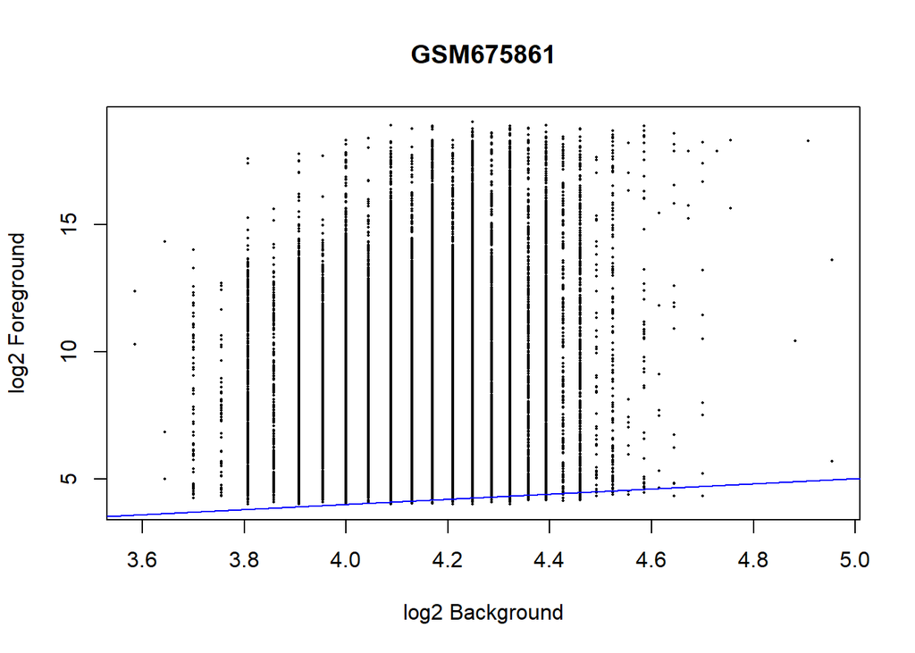

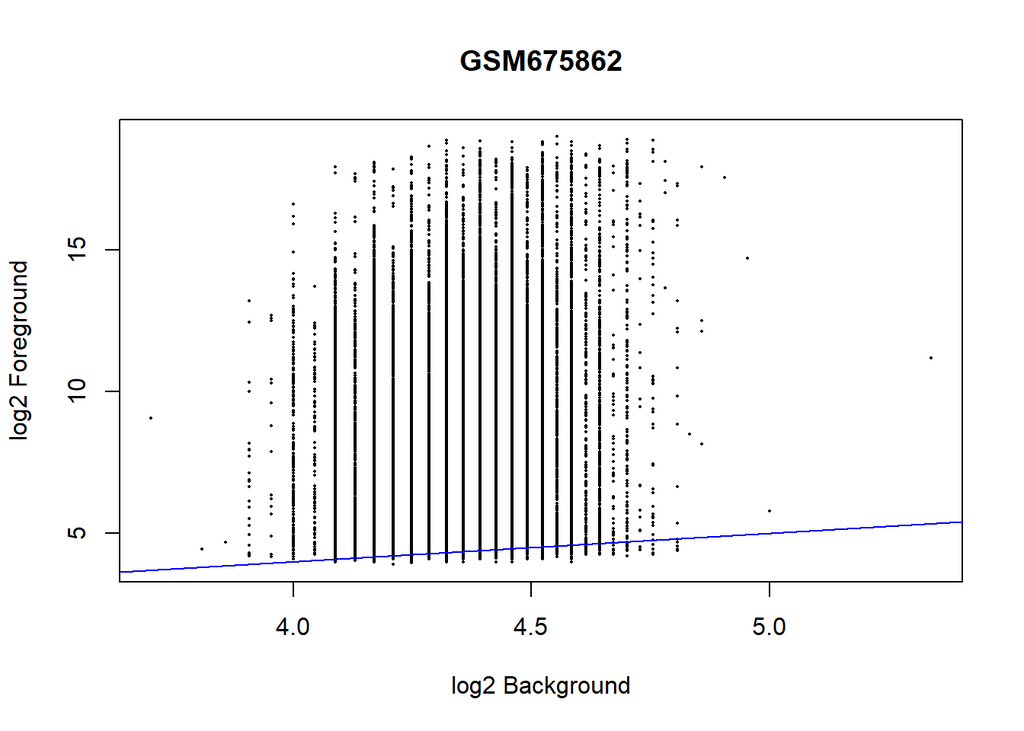

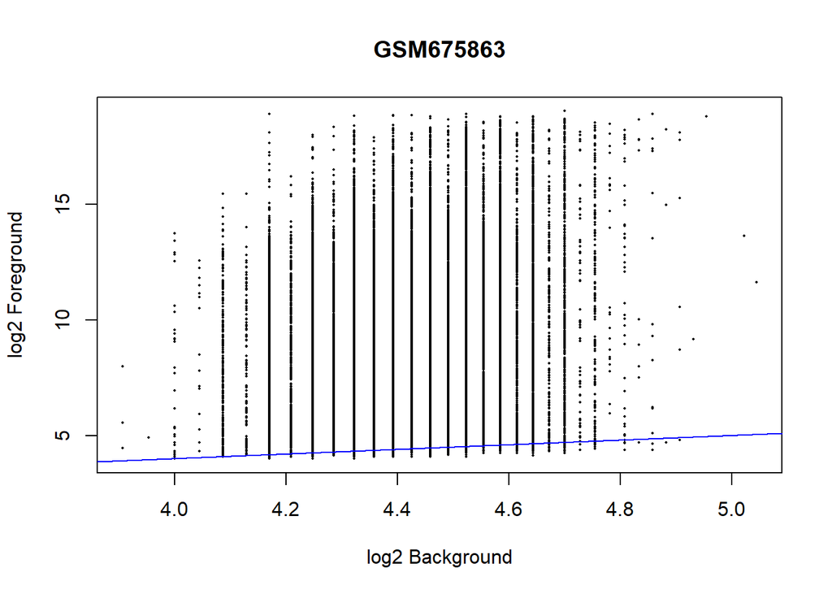

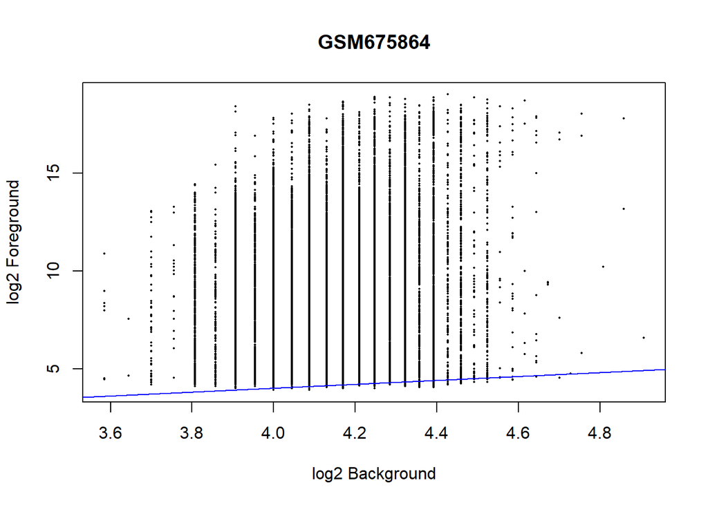

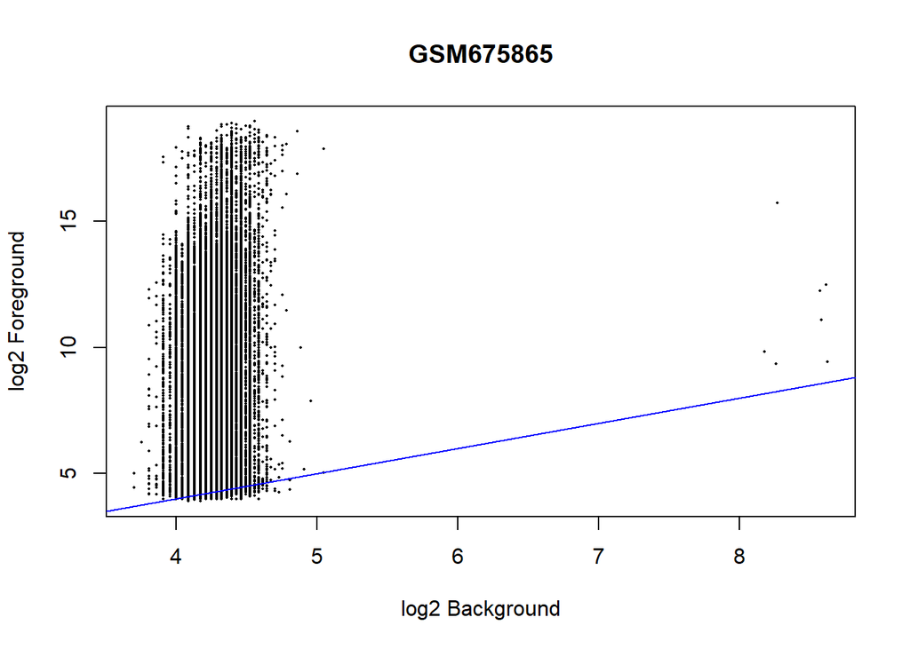

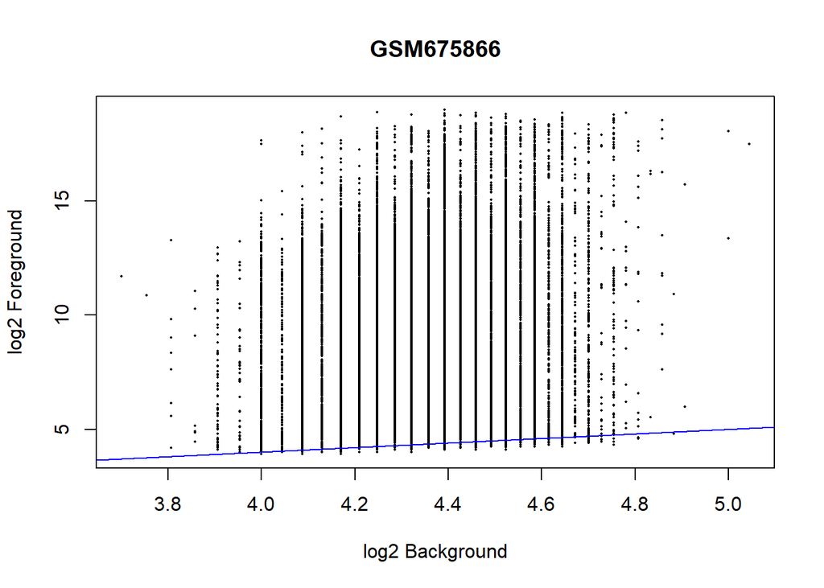

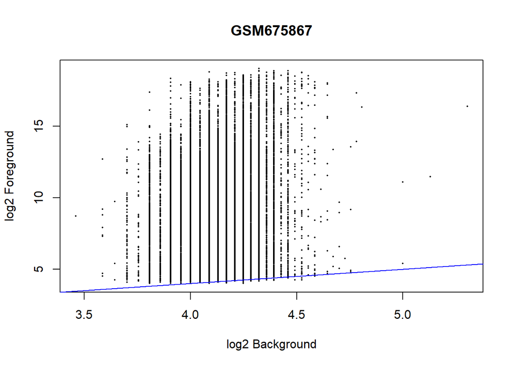

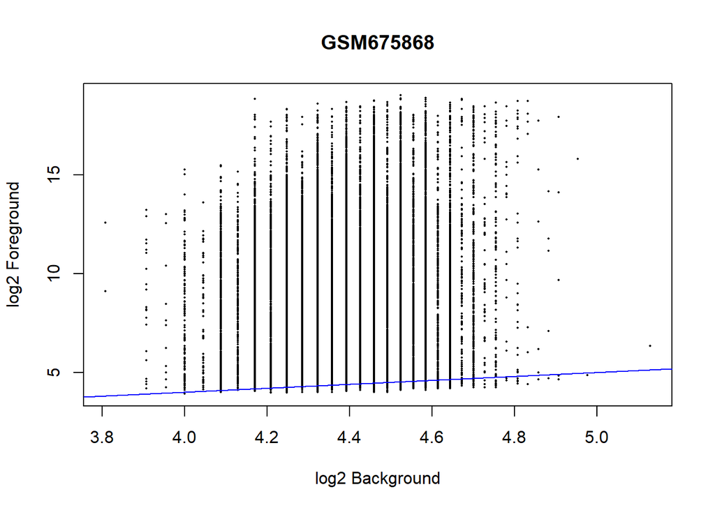

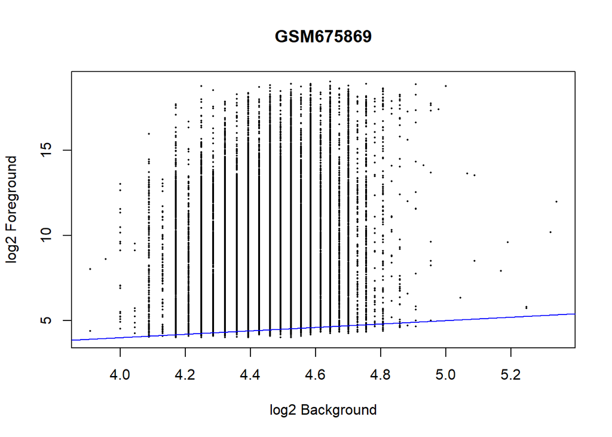

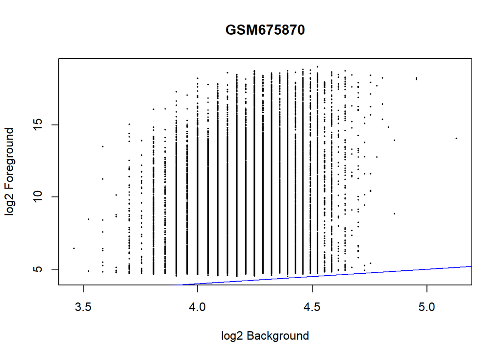

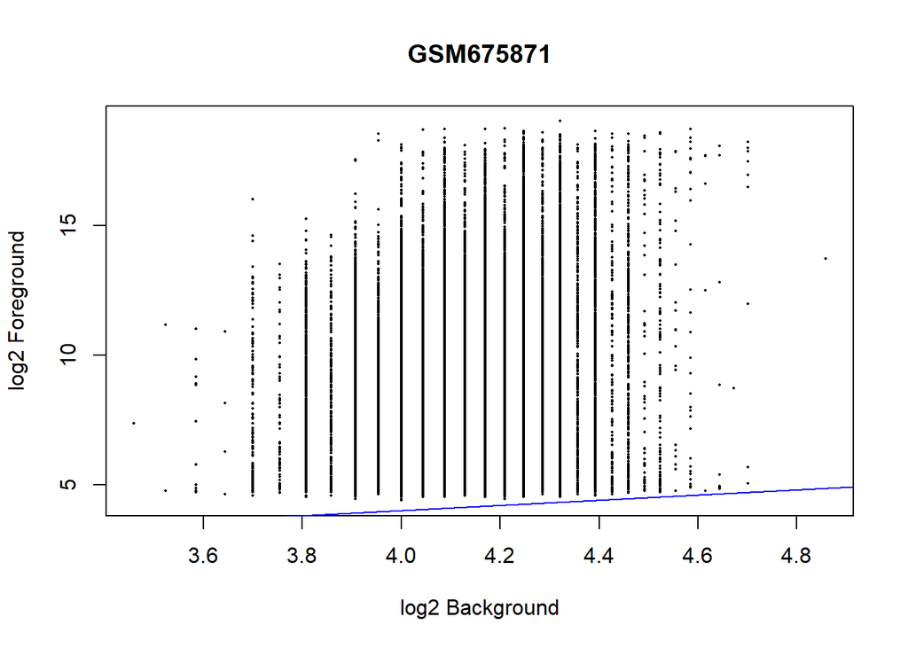

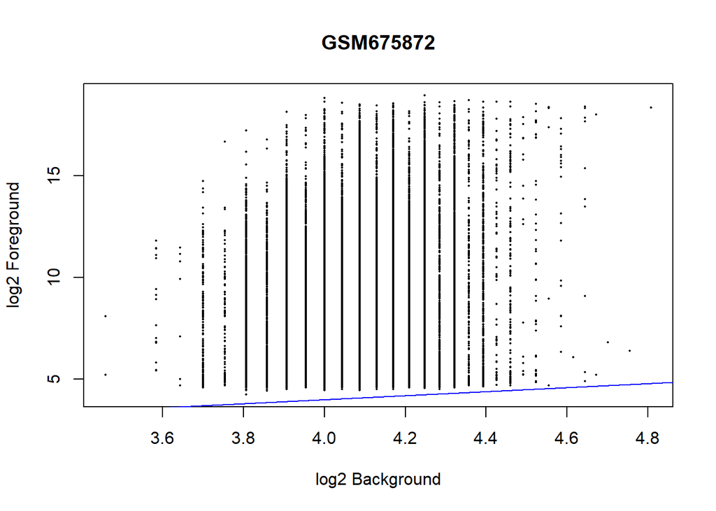

[6 more figures not shown]

```r
# This code block uses the plotFB() function from limma to generate a FB plot to compare the foreground and background intensities in each sample.
count = 0
for (sample_name in colnames(raw_data$E)) {
    count = count + 1
    plotFB(raw_data, array = count, xlab = "log2 Background", ylab = "log2 Foreground", main = sample_name)
}
```

- raw_data = EListRaw object containing the raw expression values and information about the arrays
- array = specifying which array (sample) to use as the data
- xlab = label for the x axis
- ylab = label for the y axis
- main = title for the plot

## Normalization of the Data

After making sure that the raw data looks good, I had to remove the technical variation in the raw intensities that comes from external sources (i.e. Sample preparation) by performing normalization on the raw data. For this step, I was able to use a couple other functions from Limma called backgroundCorrect() to subtract the foreground intensities from the background intensities and normalizeBetweenArrays() to normalize the data.

```r
corrected_data <- limma::backgroundCorrect(raw_data, method = "normexp") # Corrects intensities for background
```

```
## Array 1 corrected
## Array 2 corrected
## Array 3 corrected
## Array 4 corrected
## Array 5 corrected
## Array 6 corrected
## Array 7 corrected
## Array 8 corrected
## Array 9 corrected
## Array 10 corrected
## Array 11 corrected
## Array 12 corrected
## Array 13 corrected
## Array 14 corrected
## Array 15 corrected
## Array 16 corrected
## Array 17 corrected
## Array 18 corrected
```

```r
# Input: Background corrected EListRaw, Output: Elist
norm_data <- normalizeBetweenArrays(corrected_data, method = "quantile") # Normalizes the data
```

- raw_data = EListRaw object containing the raw intensities and information about the arrays
- method = specifying which background correction method should be used on the raw data
- corrected_data = Background corrected EListRaw object
- method = specifying which normalization method should be done on the data

## QA of the Normalized Data

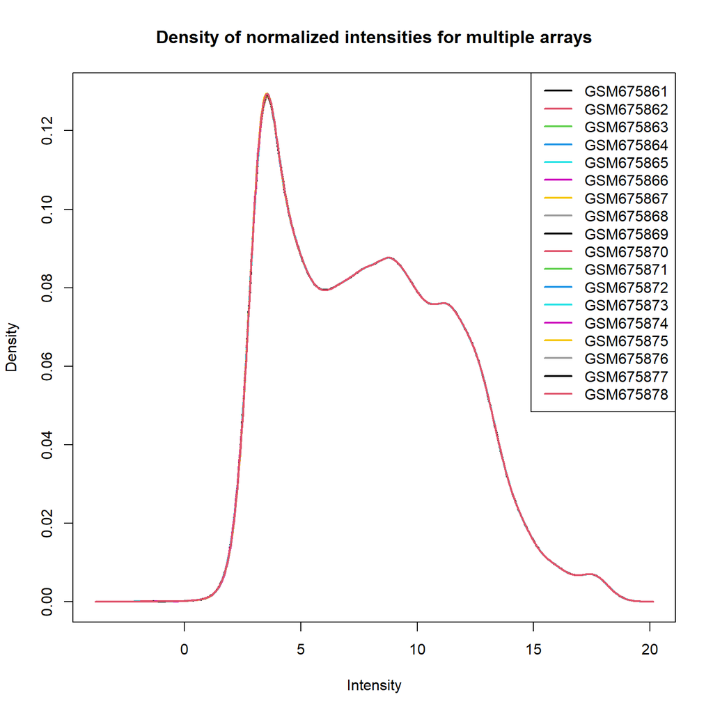

```r
plotDensities(norm_data, log = TRUE, legend = "topright" , main = "Density of normalized intensities for multiple arrays")
```

- norm_data = EList object containing normalized intensities and information about the arrays
- log = Specifying the densities should be plotted on the log2 scale
- legend = Specifying where the legend should be placed on the graph
- main = title of the graph

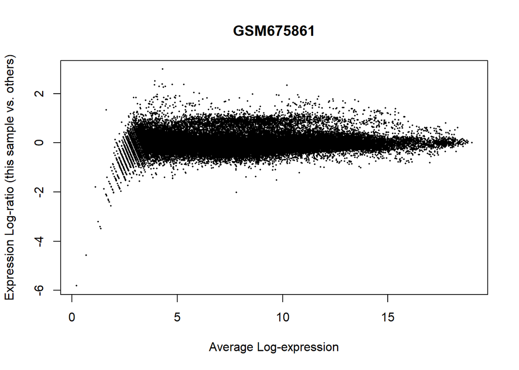

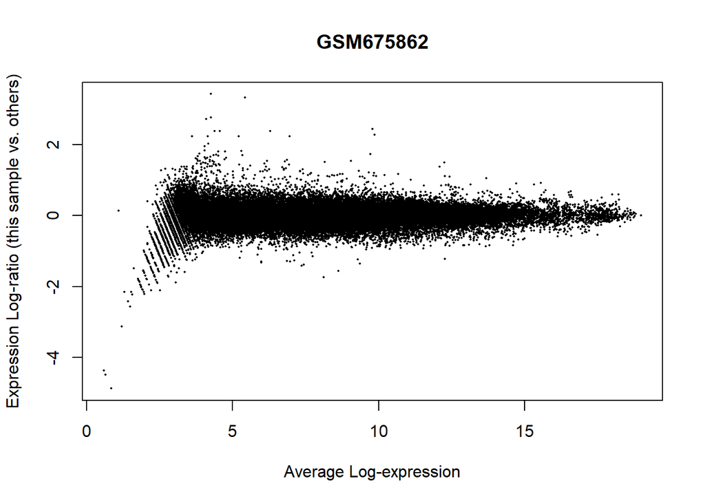

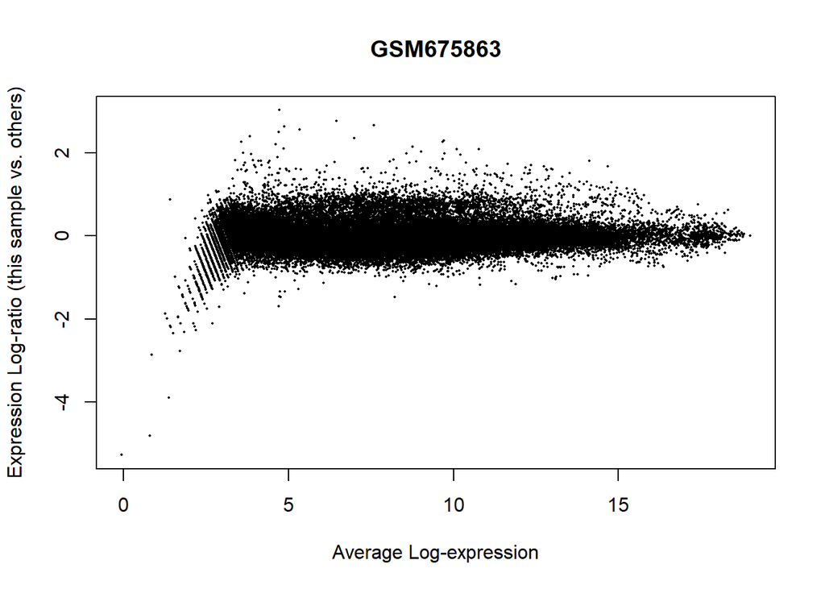

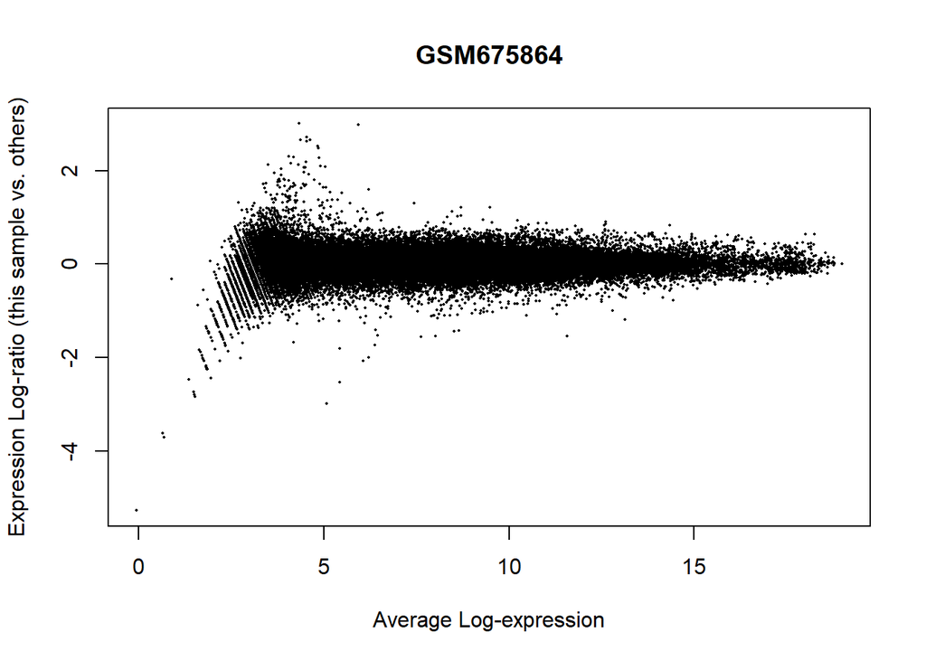

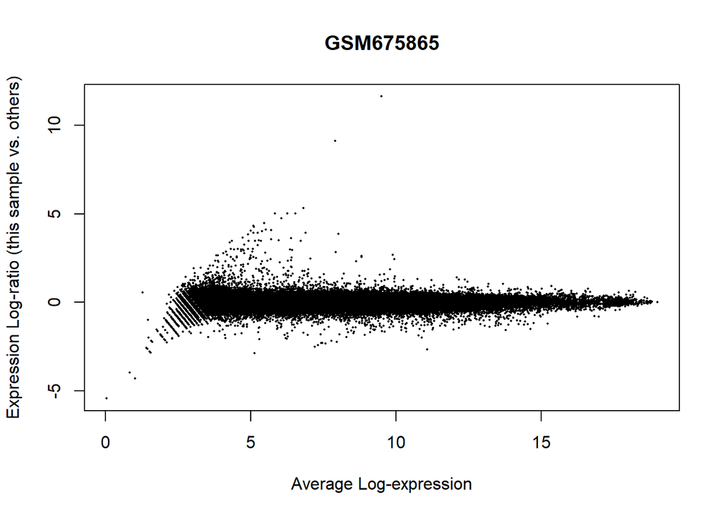

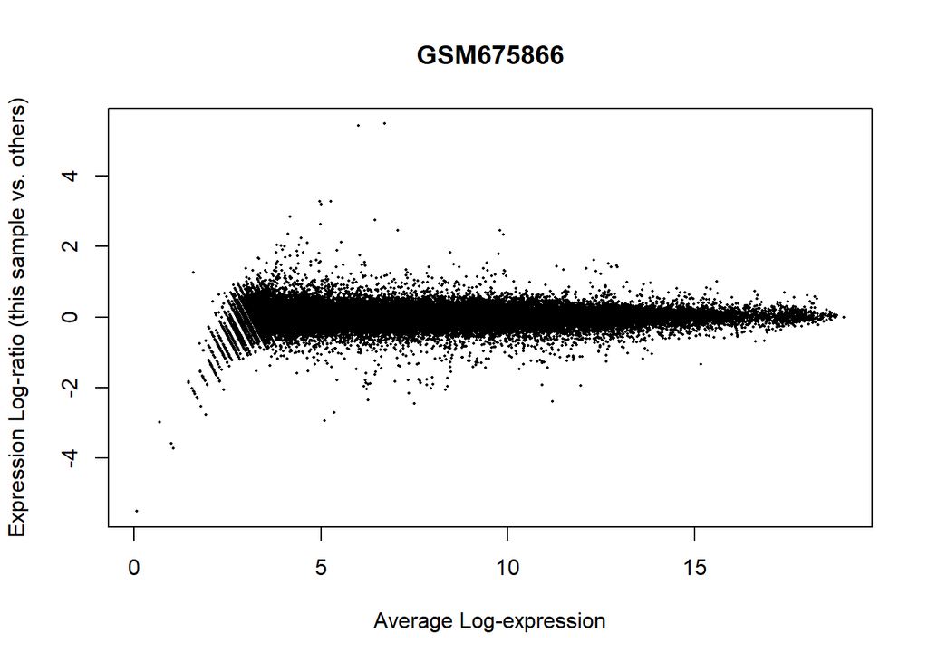

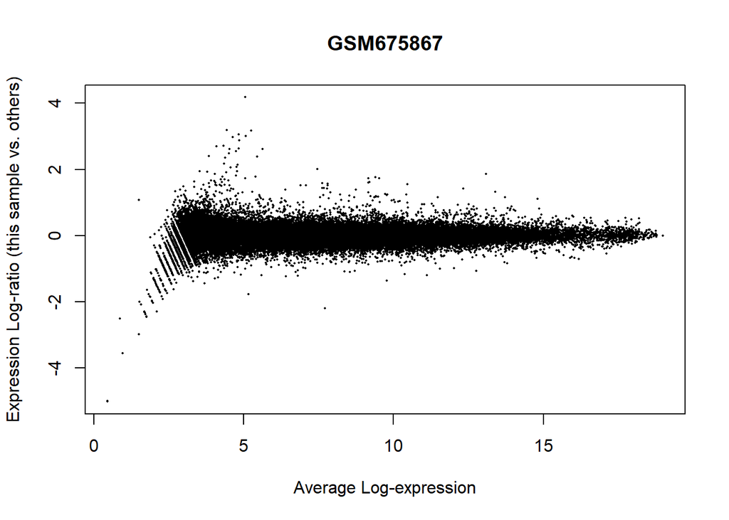

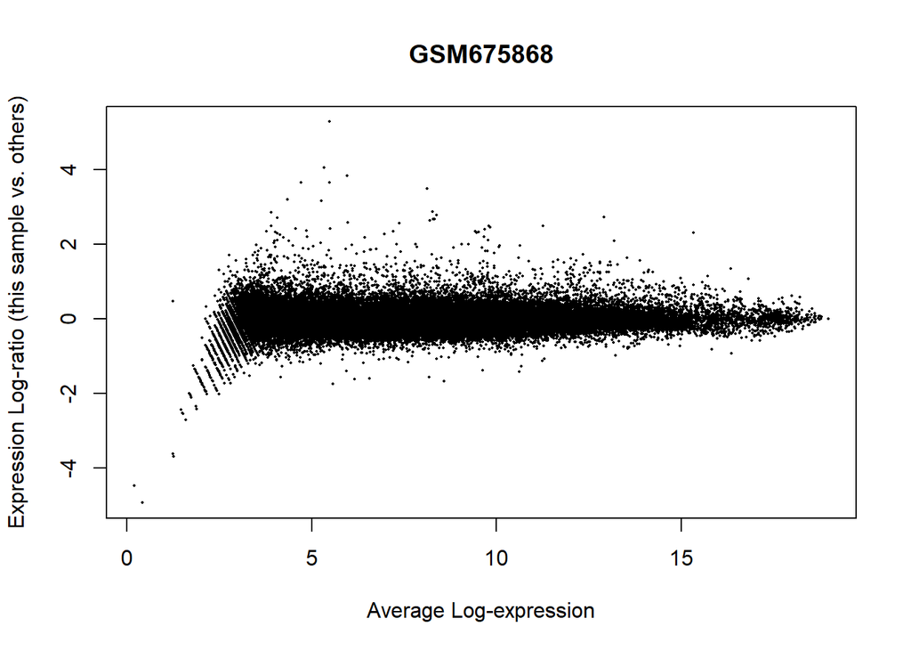

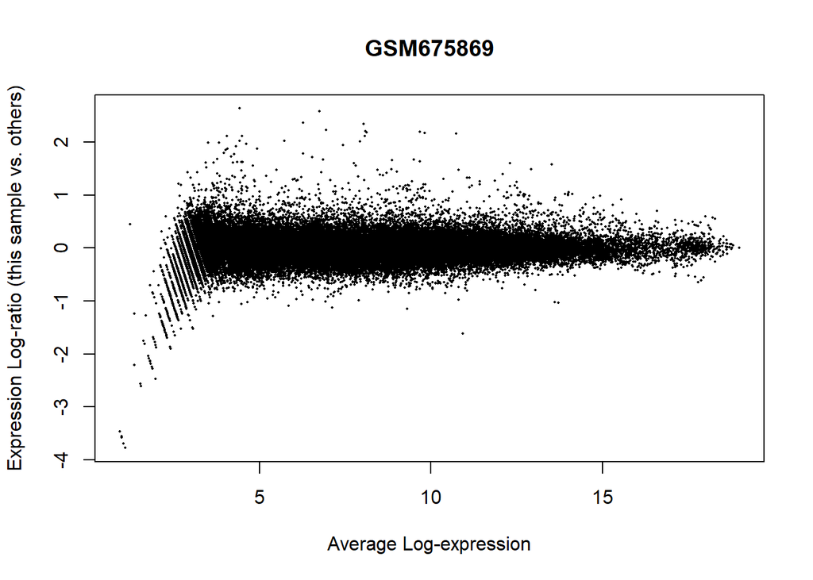

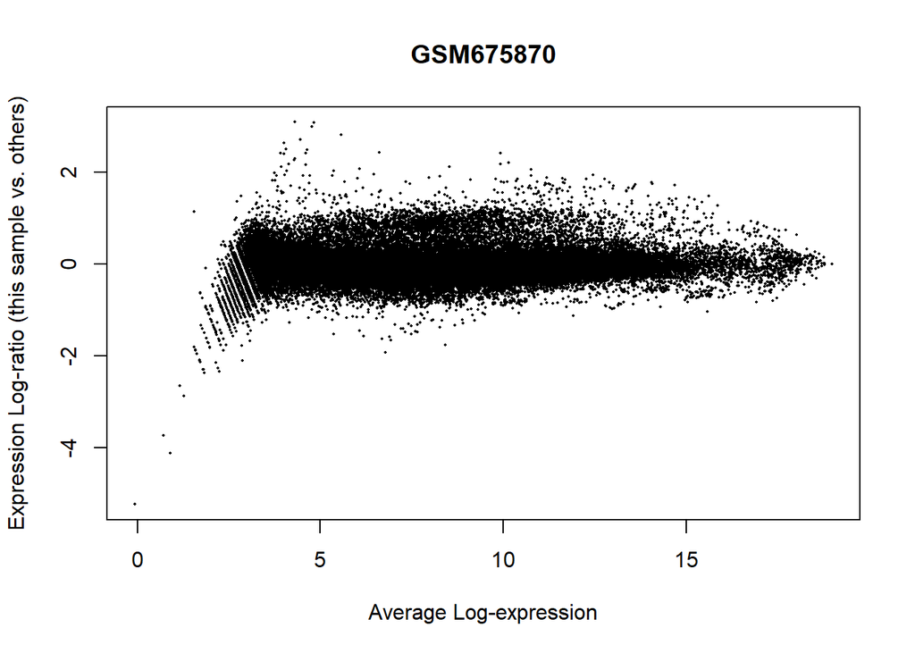

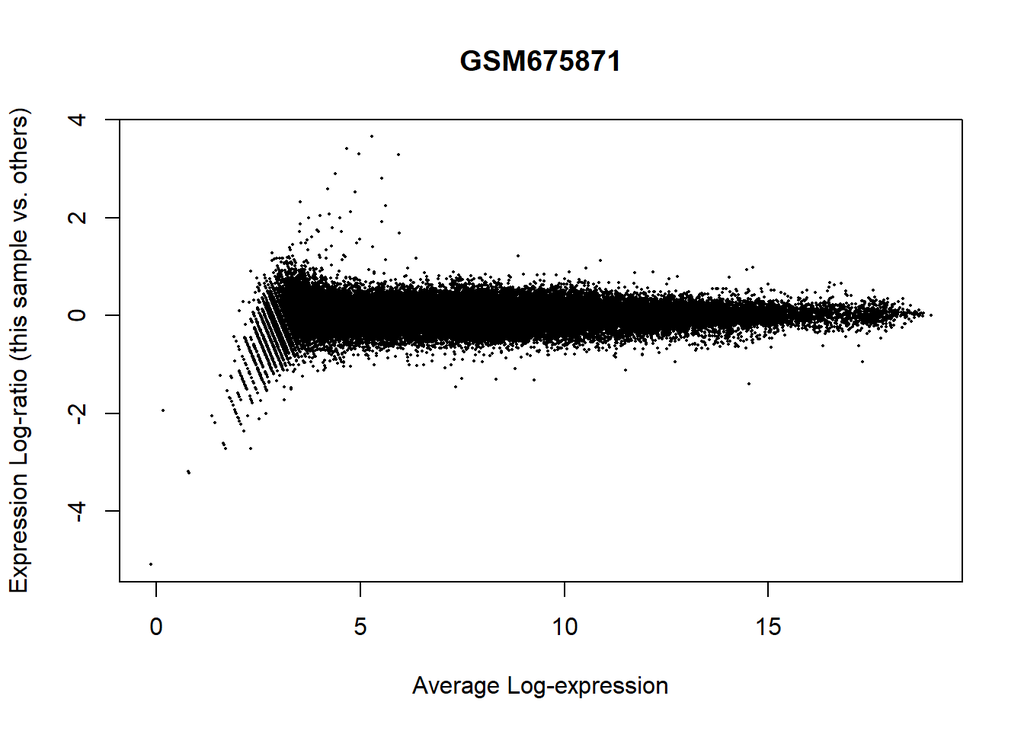

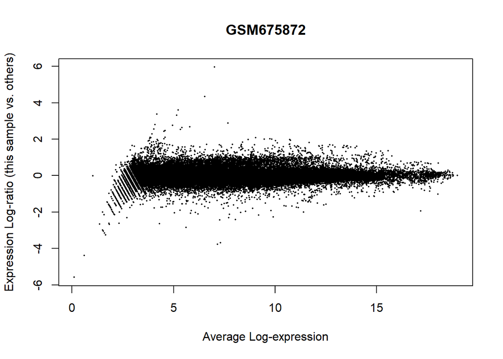

[6 more figures not shown]

```r
count = 0
for (sample_name in colnames(raw_data$E)) {
    count = count + 1
    limma::plotMA(norm_data, array = count, xlab = "Average Log-expression", ylab = "Expression Log-ratio (this sample vs. others)", main = sample_name)
}
```

- norm_data = EList object containing normalized intensities and information about the arrays
- array = choosing which array (sample) to use the data from
- xlab = label for the x axis
- ylab = label for the y axis
- main = title for the plot

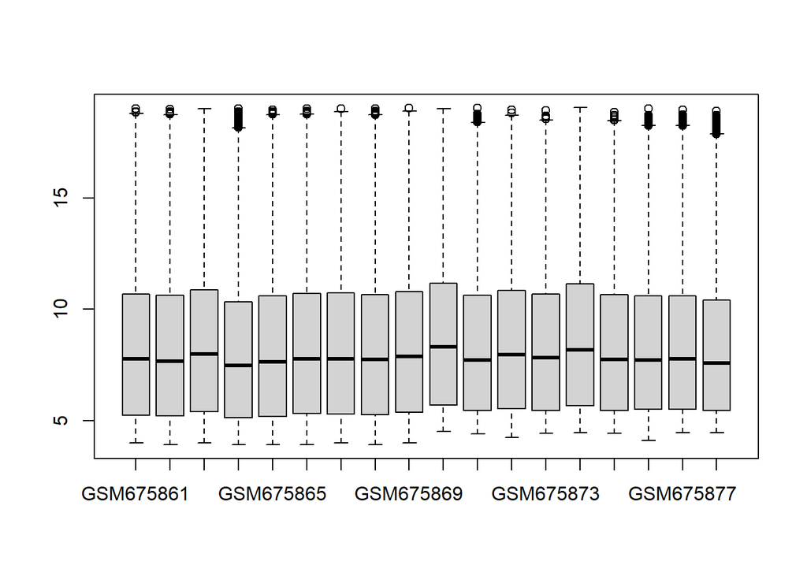

```r
boxplot(log2(raw_data$E)) # Comparing the raw data to the normalized data
```

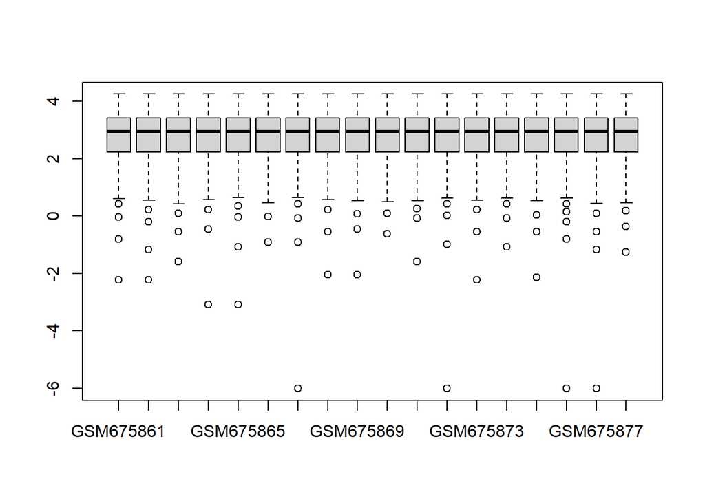

```r
suppressWarnings(boxplot(log2(norm_data$E)))
```

- raw_data$E = Raw intensities
- norm_data$E = Normalized intensities

## Generating Probe and Gene Level Data

```r
# Generating Raw probe level data
raw_intensities_df <- as.data.frame(raw_data$E, row.names = raw_data$genes$GeneName, col.names = colnames(raw_data$E))# Generates a dataframe containing the raw intensities with the genes as the rows and samples as column names.
raw_probe_level_data_df <- cbind(raw_data$genes, raw_intensities_df)
write.csv(raw_probe_level_data_df, file = file.path(dir, "/output_data/GLDS-41_output_data/Raw_probe_level_data-GLDS-41.csv"), row.names = FALSE)
```

- raw_intensities_df = Variable containing the raw intensities (raw_data$E)
- row.names = Making the row names the names of the genes
- col.names = Making the column names the sample names
- raw_probe_level_data_df = Dataframe containing the raw intensities with information about each gene
- file = Choosing the output location of the csv file and the name for the file
- row.names = Telling R whether or not to export the row names into the csv file

```r
# Generating raw gene level data
first_sample_raw_mean = paste0(colnames(raw_data$E)[1], "_mean")
sample_one_raw = colnames(raw_data$E)[1]
summarized_columns_raw <- raw_probe_level_data_df %>% group_by(GeneName) %>% summarize(!!first_sample_raw_mean := mean(get(sample_one_raw))) # Using this data frame to merge with
for (sample_name_raw in colnames(raw_data$E)) {
    print(sample_name_raw)
    sample_name_mean = paste0(sample_name_raw,"_mean")
    sample_name_sd = paste0(sample_name_raw,"_sd")
    sample_name_median = paste0(sample_name_raw,"_median")
    summarized_columns_raw <- merge(summarized_columns_raw, raw_probe_level_data_df %>% group_by(GeneName) %>% summarize(!!sample_name_mean := mean(get(sample_name_raw)), !!sample_name_sd := sd(get(sample_name_raw)), !!sample_name_median := median(get(sample_name_raw)), .groups = "keep"))
    } # This is where I'm merging the other data frames to the first one, to generate 1 data frame with all of the columnes (Gene_name, sample_mean, sample_sd, sample_median)
```

```
## [1] "GSM675861"
## [1] "GSM675862"
## [1] "GSM675863"
## [1] "GSM675864"
## [1] "GSM675865"
## [1] "GSM675866"
## [1] "GSM675867"
## [1] "GSM675868"
## [1] "GSM675869"
## [1] "GSM675870"
## [1] "GSM675871"
## [1] "GSM675872"
## [1] "GSM675873"
## [1] "GSM675874"
## [1] "GSM675875"
## [1] "GSM675876"
## [1] "GSM675877"
## [1] "GSM675878"
```

```r
write.csv(summarized_columns_raw, file = file.path(dir, paste0("/output_data/GLDS-41_output_data/Raw_gene_level_data-GLDS-41.csv")), row.names = FALSE)
```

- first_sample_raw_mean = Variable containing the name of the first sample followed by _mean. Used to name the column
- sample_one_raw = Variable containing the name of the first sample
- summarized_columns_raw = Dataframe that will contain all of the summarized gene level information (GeneName, mean, SD, median)
- sample_name_raw = Variable that contains the current sample
- sample_name_mean = Variable that holds the current sample name followed by _mean. Used to name the column.
- sample_name_sd = Variable that holds the current sample name followed by _sd. Used to name the column.
- sample_name_median = Variable that holds the current sample name followed by _median. Used to name the column.
- .groups = Tells the function what to do about the grouping structure from the dataframe that it is getting the information from

```r
# Generating Normalized probe level data
norm_intensities_df <- as.data.frame(norm_data$E, row.names = norm_data$genes$GeneName, col.names = colnames(norm_data$E))
norm_probe_level_data_df <- cbind(norm_data$genes, norm_intensities_df)
write.csv(norm_probe_level_data_df, file = file.path(dir, "/output_data/GLDS-41_output_data/Normalized_probe_level_data-GLDS-41.csv"), row.names = FALSE)
```

- norm_intensities_df = Variable containing the normalized intensities (norm_data$E)
- row.names = Making the row names the names of the genes
- col.names = Making the column names the sample names
- norm_probe_level_data_df = Dataframe containing the normalized intensities with information about each gene
- file = Choosing the output location of the csv file and the name for the file
- row.names = Telling R whether or not to export the row names into the csv file

```r
# Generating normalized gene level data
first_sample_norm_mean = paste0(colnames(norm_data$E)[1], "_mean")
sample_one_norm = colnames(norm_data$E)[1]
summarized_columns_norm <- norm_probe_level_data_df %>% group_by(GeneName) %>% summarize(!!first_sample_norm_mean := mean(get(sample_one_norm)))
for (sample_name_norm in colnames(norm_data$E)) {
    print(sample_name_norm)
    sample_name_mean = paste0(sample_name_norm, "_mean")
    sample_name_sd = paste0(sample_name_norm, "_sd")
    sample_name_median = paste0(sample_name_norm, "_median")
    summarized_columns_norm <- merge(summarized_columns_norm, norm_probe_level_data_df %>% group_by(GeneName) %>% summarize(!!sample_name_mean := mean(get(sample_name_norm)), !!sample_name_sd := sd(get(sample_name_norm)), !!sample_name_median := median(get(sample_name_norm)), .groups = "keep"))
    }
```

```
## [1] "GSM675861"
## [1] "GSM675862"
## [1] "GSM675863"
## [1] "GSM675864"
## [1] "GSM675865"
## [1] "GSM675866"
## [1] "GSM675867"
## [1] "GSM675868"
## [1] "GSM675869"
## [1] "GSM675870"
## [1] "GSM675871"
## [1] "GSM675872"
## [1] "GSM675873"
## [1] "GSM675874"
## [1] "GSM675875"
## [1] "GSM675876"
## [1] "GSM675877"
## [1] "GSM675878"
```

```r
write.csv(summarized_columns_norm, file = file.path(dir, "/output_data/GLDS-41_output_data/Normalized_gene_level_data-GLDS-41.csv"), row.names = FALSE)
```

- first_sample_norm_mean = Variable containing the name of the first sample followed by _mean. Used to name the column
- sample_one_norm = Variable containing the name of the first sample
- summarized_columns_norm = Dataframe that will contain all of the summarized gene level information (GeneName, mean, SD, median)
- sample_name_norm = Variable that contains the current sample
- sample_name_mean = Variable that holds the current sample name followed by _mean. Used to name the column.
- sample_name_sd = Variable that holds the current sample name followed by _sd. Used to name the column.
- sample_name_median = Variable that holds the current sample name followed by _median. Used to name the column.
- .groups = Tells the function what to do about the grouping structure from the dataframe that it is getting the information from

```r
control_probes <- norm_data$genes$ControlType==1L # Removes control probes
IsExpr <- rowSums(norm_data$other$gIsWellAboveBG > 0) >= 4 # Removes probes that don't appear to be expressed
unmapped_probes <- raw_probe_level_data_df$GeneName == raw_probe_level_data_df$ProbeName # Removes probes where the ProbeName is also the GeneName
norm_data_filtered <- norm_data[!control_probes & !unmapped_probes & IsExpr, ]
```

- control_probes = Contains the rows of genes where the ControlType column == 1
- IsExpr = Only contains the genes where the foreground is much greater than the background intensity. This means that the probe is expressed.
- unmapped_probes = Contains the probes where the GeneName is the same as the ProbeName column.
- norm_data_filtered = Filters out the rows with the control probes and unmapped probes while retaining the rows that are expressed.

## Differential Gene Analysis

```r
number_of_probes = nrow(norm_data_filtered)
design <- model.matrix(~ 0 + levels)
fit <- lmFit(norm_data_filtered, design)

fit.groups <- colnames(fit$design)[which(fit$assign == 1)]
# fit.index <-  which(levels(levels) %in% fit.groups)
fit.group.names <- gsub(" ", "_", sub(", ", "_", unique(GLDS_41_rs$`Factor Value[gravity]`)))

### Create Contrast Model
cat("\nCreating contrast model\n")
```

```
##
## Creating contrast model
```

```r
combos<-combn(fit.groups,2) # generate matrix of pairwise group combinations for comparison
combos.names<-combn(fit.group.names,2)
contrasts<-c(paste(combos[1,],combos[2,],sep = "-"),paste(combos[2,],combos[1,],sep = "-")) # format combinations for limma:makeContrasts
contrast.names <- c(paste(combos.names[1,],combos.names[2,],sep = "v"),paste(combos.names[2,],combos.names[1,],sep = "v")) # format combinations for output table file names

cont.matrix <- makeContrasts(contrasts=contrasts,levels=design)


contrast.fit <- contrasts.fit(fit, cont.matrix)
contrast.fit <- eBayes(contrast.fit)
# TODO: 1. See if the values are pairwise values are Log2FC (rename it if so), 2. If not, figure out how to get Log2FC
summary(decideTests(contrast.fit[,-1]))
```

```
##        levelsControl.Groups-levelsWeightlessness
## Down                                        2930
## NotSig                                     31224
## Up                                          2778
##        levelsGravity..Altered-levelsWeightlessness
## Down                                          3050
## NotSig                                       29937
## Up                                            3945
##        levelsGravity..Altered-levelsControl.Groups
## Down                                          1783
## NotSig                                       32341
## Up                                            2808
##        levelsWeightlessness-levelsControl.Groups
## Down                                        2778
## NotSig                                     31224
## Up                                          2930
##        levelsWeightlessness-levelsGravity..Altered
## Down                                          3945
## NotSig                                       29937
## Up                                            3050
```

```r
result_table <- topTable(contrast.fit, number = number_of_probes)
```

- number_of_probes = Variable that contains the number of rows in the norm_data_filtered variable.
- design = Variable containing the control and experimental groups (factor values) as levels (categorical variables).
  - levels = Factor values stored as levels (categorical variables).
- fit = Variable containing the MArrayLM object created by lmFit. Contains the result of fitting gene-wise linear models to the normalized intensities / log ratios.
  - norm_data_filtered = Normalized data where control probes, unmapped probes are removed and only the expressed probes are included.
- fit.groups = Variable containing the names of the levels of the experiment (control group and experimental groups). The names are in a format that is usable by R.
- fit.group.names = Variable containing the names of the levels of the experiment (control and experimental group). The names are not in a format that is usable by R (more human readable).
- combos = Matrix of the pairwise group combinations for comparison
- combos.names = Matrix of the pairwise group combinations for comparison using the group names that are more human readable.
- contrasts = Formatting the combinations to be used in the makeContrasts function.
- contrasts.names = Formatting the combinations to be used in the makeContrasts function using the group names that are more human readable and a ‘v’ rather than a dash to separate the pairwise combinations.
- cont.matrix = Matrix containing pairwise combinations created by the makeContrasts function.
- contrast.fit = MArrayLM object containing the statistics (T-statistics, F-statistics, and log-odds of differential experession) as well as the contrasts (pairwise combinations).
- results_table = Matrix that contains the genes that are significantly differentially expressed for each contrast. Contains the gene information, contrast information, and DGE information (P-values, Ave Expr, F, etc.).

## Adding Gene Annotations

```r
listEnsembl()
```

```
##         biomart                version
## 1         genes      Ensembl Genes 107
## 2 mouse_strains      Mouse strains 107
## 3          snps  Ensembl Variation 107
## 4    regulation Ensembl Regulation 107
```

```r
ensembl <- useEnsembl(biomart = "genes") # Making a mart object (points to the data that is hosted on Ensembl website)
ensembl
```

```
## Object of class 'Mart':
##   Using the ENSEMBL_MART_ENSEMBL BioMart database
##   No dataset selected.
```

```r
searchDatasets(mart = ensembl, pattern = "[Cc]aenorhabditis elegans") # Pattern = organism of interest
```

```
##                  dataset                                          description
## 29 celegans_gene_ensembl Caenorhabditis elegans (PRJNA13758) genes (WBcel235)
##     version
## 29 WBcel235
```

```r
ensembl <- useDataset(dataset = "celegans_gene_ensembl", mart = ensembl) # Selecting the dataset

searchAttributes(mart = ensembl, pattern = "agilent_") # Look at comments of ADF file to figure out which attribute to use
```

```
##                name            description         page
## 62   agilent_012795   AGILENT 012795 probe feature_page
## 63   agilent_015061   AGILENT 015061 probe feature_page
## 64   agilent_020186   AGILENT 020186 probe feature_page
## 65 agilent_gpl13394 AGILENT GPL13394 probe feature_page
## 66 agilent_gpl13914 AGILENT GPL13914 probe feature_page
## 67 agilent_gpl14144 AGILENT GPL14144 probe feature_page
## 68 agilent_gpl19516 AGILENT GPL19516 probe feature_page
## 69  agilent_gpl8304  AGILENT GPL8304 probe feature_page
```

```r
my_agilent_ids <- norm_data_filtered$genes$ProbeName
results <- getBM(
    attributes = c(
        "agilent_020186", # Name of the array from the ADF file (Write a markdown file about how I found the array name)
        "ensembl_gene_id",
        "uniprot_gn_symbol",
        "go_id"
        ), filters = "agilent_020186",
        values = c(my_agilent_ids),
        mart = ensembl)

unique_probe_ids <- results %>% group_by(agilent_020186) %>%
                      summarise(
                        SYMBOL = toString(unique(uniprot_gn_symbol)),
                        ENSEMBL = toString(unique(ensembl_gene_id)),
                        GO_Ids = toString(unique(go_id))
                        )

# Join tables
bound_columns <- bind_cols(norm_data_filtered$E, norm_data_filtered$genes$ProbeName) %>% rename("ProbeName" = paste0("...", ncol(norm_data_filtered)+1))
compiled_table <- result_table %>% left_join(unique_probe_ids, by = c("ProbeName" = "agilent_020186")) %>% left_join(bound_columns)
write.csv(compiled_table, file = file.path(dir, "/output_data/GLDS-41_output_data/Probe_level_annotated_DGE_with_Normalized_Intensities_GLDS_41.csv"), row.names = FALSE)
```

- listEnsembl = Lists the databases that Ensembl has.
- ensembl = Variable containing the mart object that points to the data that is hosted on the Ensembl website.
  - biomart = “genes” - Specifying that we want to use the gene database from Ensembl.
- searchDatasets - Lists out the datasets available in the database that follow the specific pattern indicated
  - pattern = [Cc]aenorhabditis elegans” - Specifying which organism dataset we want to look for in the database.
- dataset = “celegans_gene_ensembl” - Choosing the dataset from the list of available datasets for that organism.
- searchAttributes - A function that looks for the attribute that is specified in the pattern argument.
  - pattern = “agilent_ - Making the function look for attributes that contain”agilent_” in them.
- bound_columns = Matrix that links the normalized intensity values to their corresponding probe name.
  - rename(“ProbeName” = paste0(“…”, ncol(norm_data_filtered)+1)) - Replacing the R generated column name with “ProbeName”.
- compiled_table = Table that contains the merged DGE, normalized intensites, and gene annotations.
  - by = c(“ProbeName” = “agilent_020186”) - Telling the function left_join how to join the two tables. In this case we’re telling the function to use the ProbeName column from result_table and the “agilent_020186” column (probe names) from unique_probe_ids.
- write.csv = Creates a CSV file containing the DGE, gene annotations, and normalized intensities into the specified output file.